# King County Housing Data Template

Alan Arnholt

October 21, 2021 at 09:51:51 AM

```r
housedata <- read.csv("../Data/housedata.csv",
                      colClasses = c(id = "character", date = "character",
                                     yr_built = "character", zipcode = "factor", grade = "factor"))
housedata$date <- as.Date(housedata$date, "%Y%m%d")
housedata$waterfront <- factor(housedata$waterfront, labels = c("No", "Yes"))
housedata$condition <- factor(housedata$condition, labels = c("poor", "fair", "average", "good", "very good"))
housedata$yr_renovated <- ifelse(housedata$yr_renovated == 0, housedata$yr_built, housedata$yr_renovated)
housedata$yr_built <- as.Date(ISOdate(housedata$yr_built, 9, 1))  # Complete Year, Sept 1
housedata$yr_renovated <- as.Date(ISOdate(housedata$yr_renovated, 9, 1))  # Last renovated Year, Sept 1
housedata <- housedata[, -1]
#### Perform same steps with test set
housedataT <- read.csv("../Data/housedataTEST.csv",
                      colClasses = c(id = "character", date = "character",
                                     yr_built = "character", zipcode = "factor", grade = "factor"))
housedataT$date <- as.Date(housedataT$date, "%Y%m%d")
housedataT$waterfront <- factor(housedataT$waterfront, labels = c("No", "Yes"))
housedataT$condition <- factor(housedataT$condition, labels = c("poor", "fair", "average", "good", "very good"))
housedataT$yr_renovated <- ifelse(housedataT$yr_renovated == 0, housedataT$yr_built, housedataT$yr_renovated)
housedataT$yr_built <- as.Date(ISOdate(housedataT$yr_built, 9, 1))  # Complete Year, Sept 1
housedataT$yr_renovated <- as.Date(ISOdate(housedataT$yr_renovated, 9, 1))  # Last renovated Year, Sept 1
housedataT <- housedataT[, -1]
```

```r
library(DT)
datatable(housedata[, 2:10], rownames = FALSE)
```

| price | bedrooms | bathrooms | sqft_living | sqft_lot | floors | waterfront | view | condition |
| --- | --- | --- | --- | --- | --- | --- | --- | --- |
| 221900 | 3 | 1 | 1180 | 5650 | 1 | No | 0 | average |
| 538000 | 3 | 2.25 | 2570 | 7242 | 2 | No | 0 | average |
| 180000 | 2 | 1 | 770 | 10000 | 1 | No | 0 | average |
| 604000 | 4 | 3 | 1960 | 5000 | 1 | No | 0 | very good |
| 510000 | 3 | 2 | 1680 | 8080 | 1 | No | 0 | average |
| 1225000 | 4 | 4.5 | 5420 | 101930 | 1 | No | 0 | average |
| 257500 | 3 | 2.25 | 1715 | 6819 | 2 | No | 0 | average |
| 291850 | 3 | 1.5 | 1060 | 9711 | 1 | No | 0 | average |
| 229500 | 3 | 1 | 1780 | 7470 | 1 | No | 0 | average |
| 323000 | 3 | 2.5 | 1890 | 6560 | 2 | No | 0 | average |

[output cut: 17374 more lines]

Consider predicting the price (`price`) of a house based on a certain feature (`sqft_living`). Start by graphing the relationship.

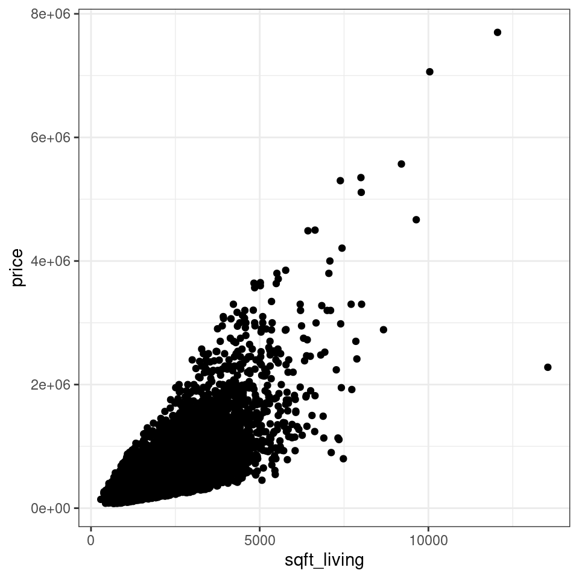

```r
library(ggplot2)
p1 <- ggplot(data = housedata, aes(x = sqft_living, y = price)) +
  geom_point() +
  theme_bw()
p1
```

Overplotting is problematic. What should we do?

- Consider making the plotting shape smaller.
- Make the points semitransparent (`alpha`).
- Bin the data into rectangles.
- Bin the data into hexagons.

### Using `alpha`

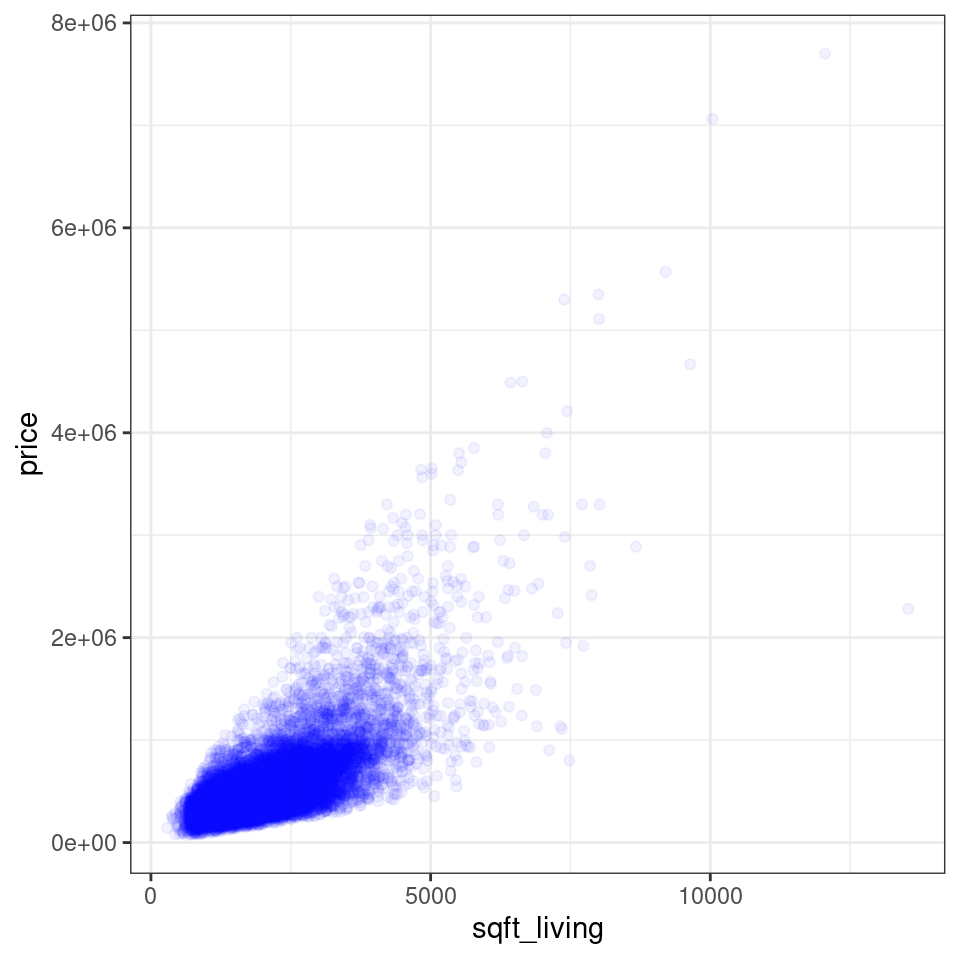

```r
p2 <- ggplot(data = housedata, aes(x = sqft_living, y = price)) +
        geom_point(alpha = 0.05, color = "blue") +
        theme_bw()
p2
```

### Using rectangles

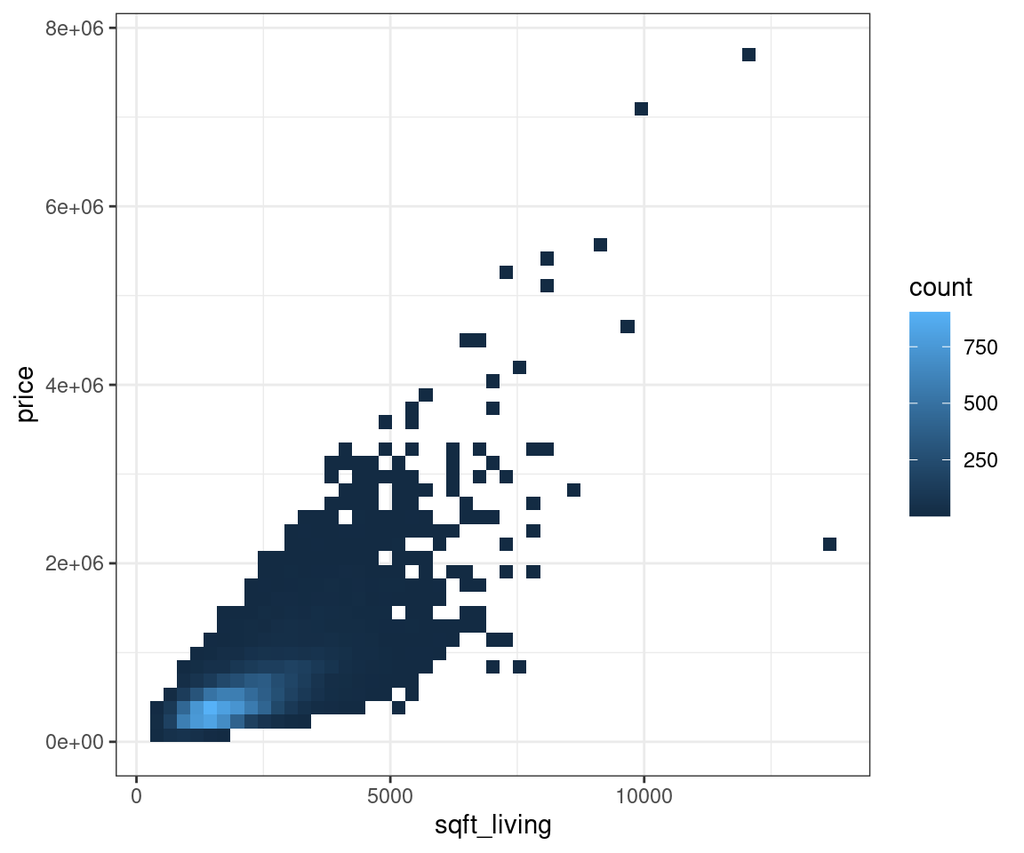

```r
p3 <- ggplot(data = housedata, aes(x = sqft_living, y = price)) +
        stat_bin2d(bins = 50) +
        theme_bw()
p3
```

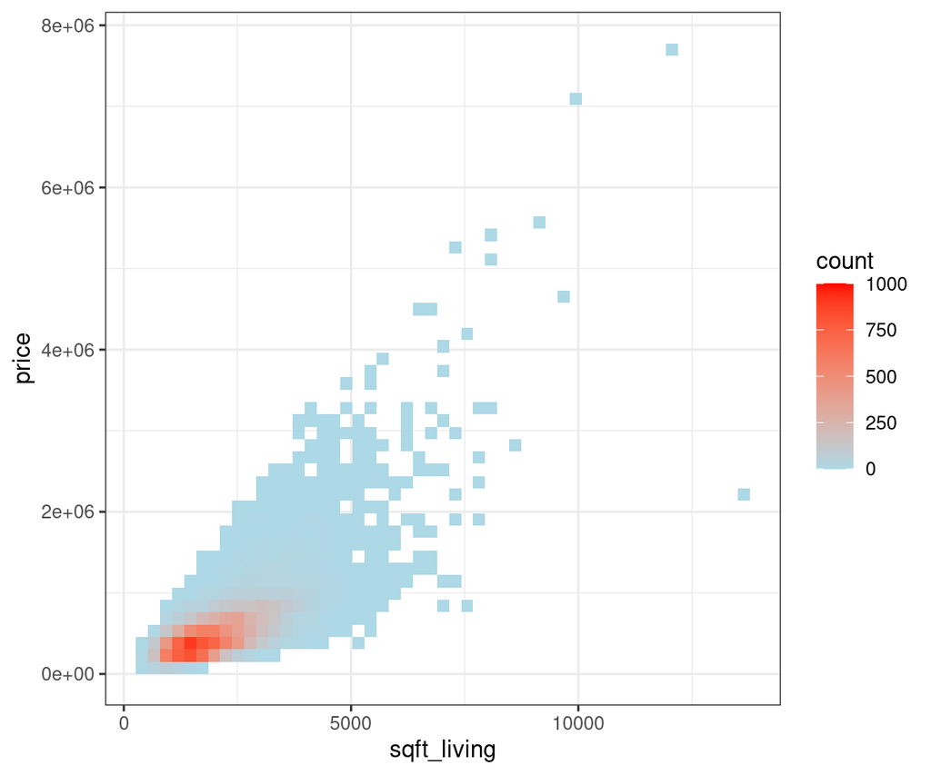

```r
p4 <- ggplot(data = housedata, aes(x = sqft_living, y = price)) +
        stat_bin2d(bins = 50) +
        scale_fill_gradient(low = "lightblue", high = "red",
                            limits = c(0, 1000)) +
        theme_bw()
p4
```

### Using hexagons

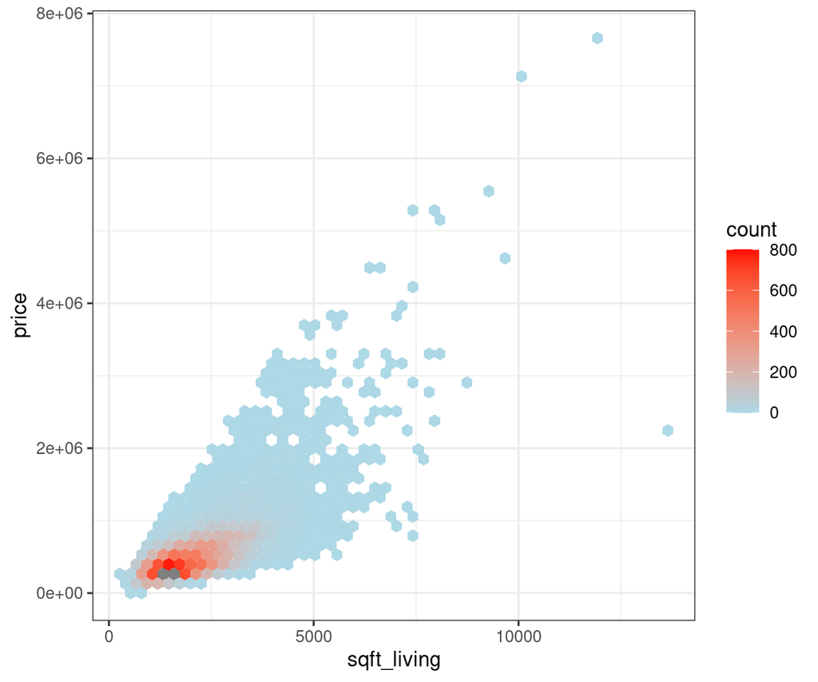

```r
p5 <- ggplot(data = housedata, aes(x = sqft_living, y = price)) +
        stat_binhex(bins = 50) +
        scale_fill_gradient(low = "lightblue", high = "red",
                            limits = c(0, 800), breaks = seq(0, 800, by = 200)) +
        theme_bw()
p5
```

**Note** For both `stat_bin2d` and `stat_binhex`, if you manually specify the range, and there is a bin that falls outside that range because it has too many of too few points, that bin will show up as grey rather than the color at the high or low end of the range. Observe the gray hexagons in the lower left corner of the above graph.

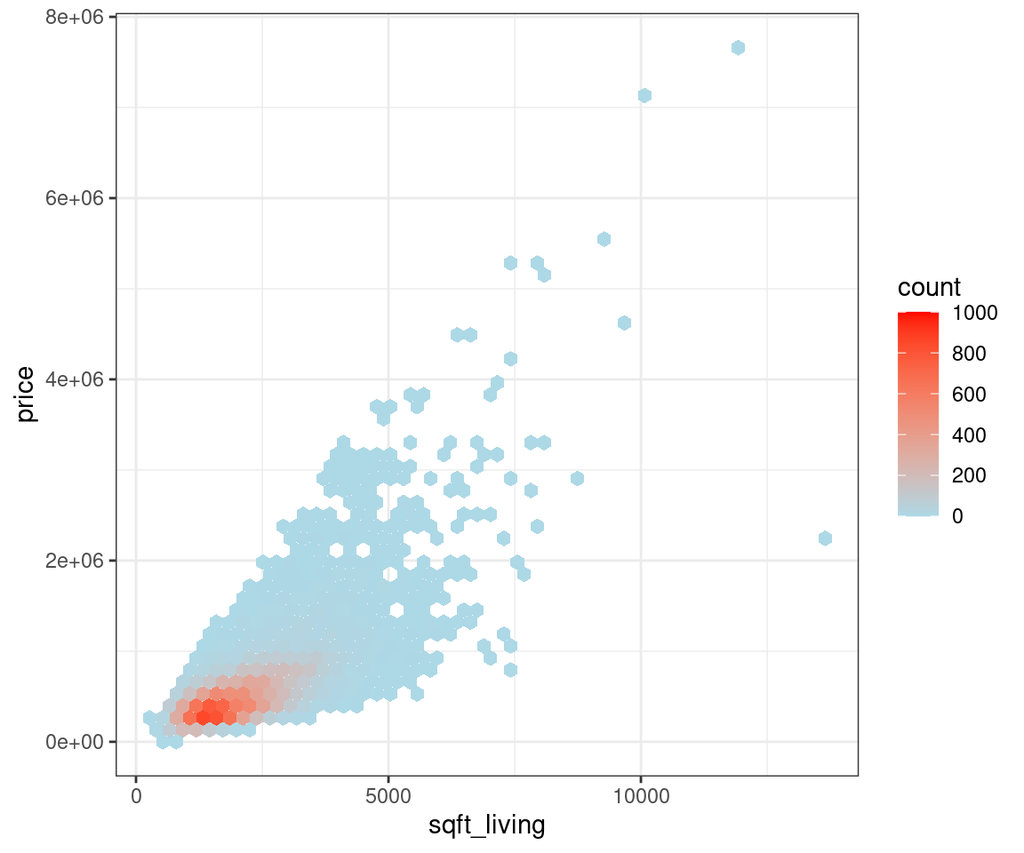

```r
p6 <- ggplot(data = housedata, aes(x = sqft_living, y = price)) +
        stat_binhex(bins = 50) +
        scale_fill_gradient(low = "lightblue", high = "red",
                            limits = c(0, 1000), breaks = seq(0, 1000, by = 200)) +
        theme_bw()
p6
```

## Example — Data Format from Building a Model

```r
library(MASS)
mod1 <- stepAIC(lm(price ~ . - sqft_basement - grade, data = housedata))
```

```
Start:  AIC=418003.6
price ~ (date + bedrooms + bathrooms + sqft_living + sqft_lot +
    floors + waterfront + view + condition + grade + sqft_above +
    sqft_basement + yr_built + yr_renovated + zipcode + lat +
    long + sqft_living15 + sqft_lot15) - sqft_basement - grade

                Df  Sum of Sq        RSS    AIC
<none>                        4.7692e+14 418004
- sqft_lot15     1 1.0139e+11 4.7702e+14 418005
- lat            1 3.0675e+11 4.7723e+14 418013
- long           1 3.8871e+11 4.7731e+14 418016
- yr_renovated   1 1.1331e+12 4.7806e+14 418043
- sqft_lot       1 1.2683e+12 4.7819e+14 418048
- yr_built       1 1.6391e+12 4.7856e+14 418061
- bathrooms      1 2.2930e+12 4.7922e+14 418085
- sqft_living15  1 2.6372e+12 4.7956e+14 418098
- date           1 3.0969e+12 4.8002e+14 418114
- floors         1 4.3875e+12 4.8131e+14 418161
- condition      4 4.9913e+12 4.8191e+14 418177
- bedrooms       1 1.1230e+13 4.8815e+14 418406
- sqft_above     1 1.7292e+13 4.9421e+14 418621
- view           1 2.2762e+13 4.9968e+14 418812
- sqft_living    1 3.9806e+13 5.1673e+14 419395
- waterfront     1 4.7657e+13 5.2458e+14 419657
- zipcode       69 3.0970e+14 7.8662e+14 426564
```

```r
summary(mod1)
```

```
Call:
lm(formula = price ~ (date + bedrooms + bathrooms + sqft_living +
    sqft_lot + floors + waterfront + view + condition + grade +
    sqft_above + sqft_basement + yr_built + yr_renovated + zipcode +
    lat + long + sqft_living15 + sqft_lot15) - sqft_basement -
    grade, data = housedata)

Residuals:
     Min       1Q   Median       3Q      Max
-1210171   -71962      875    65345  4208423

Coefficients:
                     Estimate Std. Error t value Pr(>|t|)
(Intercept)        -3.766e+07  7.072e+06  -5.324 1.03e-07 ***
date                1.190e+02  1.123e+01  10.597  < 2e-16 ***
bedrooms           -3.696e+04  1.832e+03 -20.180  < 2e-16 ***
bathrooms           2.771e+04  3.039e+03   9.119  < 2e-16 ***
sqft_living         1.531e+02  4.031e+00  37.994  < 2e-16 ***
sqft_lot            3.040e-01  4.483e-02   6.782 1.22e-11 ***
floors             -4.606e+04  3.652e+03 -12.614  < 2e-16 ***
waterfrontYes       6.722e+05  1.617e+04  41.572  < 2e-16 ***
view                5.776e+04  2.010e+03  28.730  < 2e-16 ***
conditionfair       1.011e+05  3.692e+04   2.740 0.006157 **
conditionaverage    9.938e+04  3.413e+04   2.912 0.003593 **
conditiongood       1.206e+05  3.413e+04   3.533 0.000412 ***
conditionvery good  1.663e+05  3.435e+04   4.842 1.30e-06 ***
sqft_above          1.032e+02  4.119e+00  25.041  < 2e-16 ***
yr_built           -2.359e+00  3.059e-01  -7.710 1.33e-14 ***
yr_renovated        2.006e+00  3.130e-01   6.410 1.49e-10 ***
zipcode98002        2.966e+04  1.675e+04   1.771 0.076570 .
zipcode98003       -7.230e+03  1.482e+04  -0.488 0.625640
zipcode98004        7.552e+05  2.711e+04  27.858  < 2e-16 ***
zipcode98005        2.694e+05  2.899e+04   9.292  < 2e-16 ***
zipcode98006        2.621e+05  2.361e+04  11.102  < 2e-16 ***
zipcode98007        2.223e+05  2.971e+04   7.484 7.56e-14 ***
zipcode98008        2.297e+05  2.836e+04   8.099 5.88e-16 ***
zipcode98010        9.409e+04  2.518e+04   3.736 0.000188 ***
zipcode98011        3.358e+04  3.709e+04   0.905 0.365312
zipcode98014        7.001e+04  4.095e+04   1.710 0.087361 .
zipcode98019        2.775e+04  3.988e+04   0.696 0.486515
```

[output cut: 53 more lines]

```
zipcode98177        1.261e+05  3.524e+04   3.578 0.000347 ***
zipcode98178        1.075e+03  2.055e+04   0.052 0.958296
zipcode98188        2.898e+03  2.097e+04   0.138 0.890117
zipcode98198       -2.719e+04  1.600e+04  -1.699 0.089311 .
zipcode98199        3.069e+05  2.915e+04  10.529  < 2e-16 ***
lat                 2.443e+05  7.325e+04   3.335 0.000854 ***
long               -1.957e+05  5.212e+04  -3.754 0.000174 ***
sqft_living15       3.154e+01  3.226e+00   9.779  < 2e-16 ***
sqft_lot15         -1.362e-01  7.104e-02  -1.918 0.055191 .
---
Signif. codes:  0 '***' 0.001 '**' 0.01 '*' 0.05 '.' 0.1 ' ' 1

Residual standard error: 166100 on 17295 degrees of freedom
Multiple R-squared:  0.7993,    Adjusted R-squared:  0.7982
F-statistic: 782.5 on 88 and 17295 DF,  p-value: < 2.2e-16
```

## Predicting with *TEST* data

```r
PredictedPrice <- predict(mod1, newdata = housedataT)
head(PredictedPrice)
```

```
       1        2        3        4        5        6
277523.1 857547.1 311085.6 604683.3 436416.6 536388.7
```

```r
formatSubmission <- data.frame(id = 1:4229, price = PredictedPrice)
head(formatSubmission)
```

```
  id    price
1  1 277523.1
2  2 857547.1
3  3 311085.6
4  4 604683.3
5  5 436416.6
6  6 536388.7
```

```r
write.csv(formatSubmission, "Example.csv", row.names  = FALSE)
```

Download the `Example.csv` file and upload it to kaggle to be evaluated.